# GEOG 5680 6680 Introduction to R 12 Spatial data in R

- Vegetation (NDVI > 0.4). The `clamp` function masks all value otuside of a range (here below 0.4)

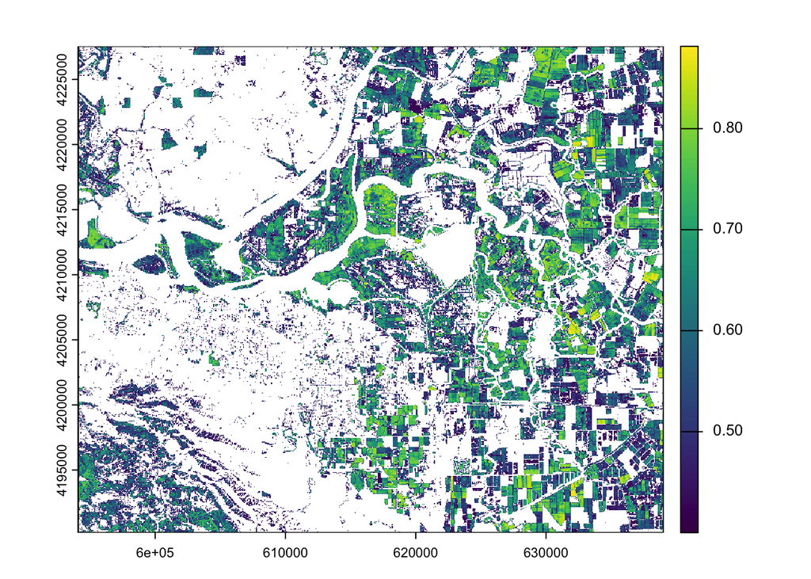

```r
veg = clamp(ndvi, lower=0.4, values=FALSE)

plot(veg)
```

- Croplands (corresponding to the peak in NDVI values):

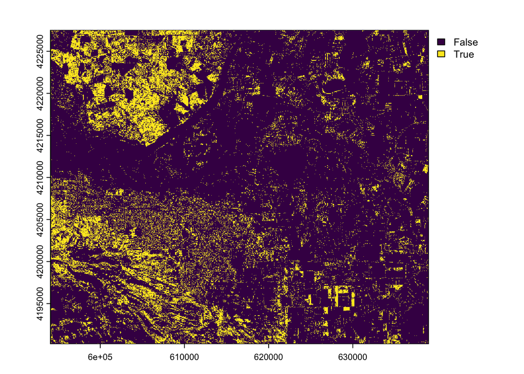

```r
crops = ndvi > 0.25 & ndvi < 0.3

plot(crops)
```

And water bodies (NDVI < 0):

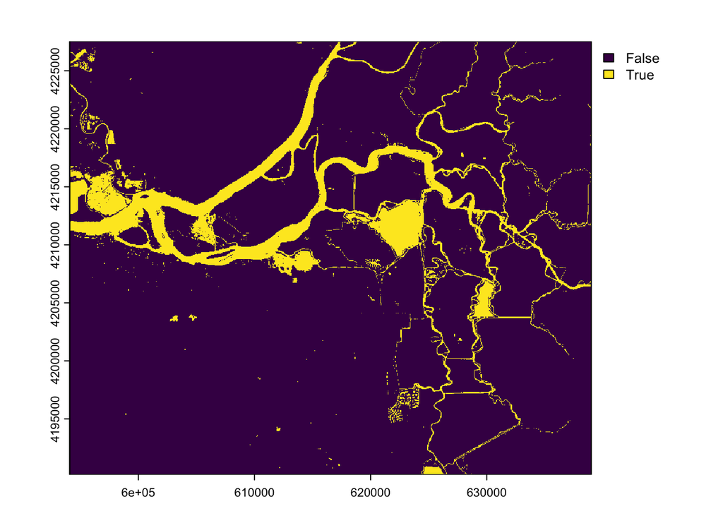

```r
water = ndvi < 0

plot(water)
```

# Exercises

The exercise for the module will get you to make some simple maps with new datasets. You should submit the results as an R script with the commands you used, and a Word (or equivalent) with any results or figures *or* as an html page generated from an R Markdown document

## Exercise 1

In the zipfile *countries.zip* is a global shapefile with various socio-economic indicators for different countries. Load this file into R and make plots of any two of the following variables (the variable names are given in brackets). Try different color scales and transformations of the data to get the most informative maps

- Median GDP: (`gdp_md_est`)
- Population: (`pop_est`)
- Income group: (`income_grp`)

## Exercise 2

Using the NDVI values you calculated in the raster section, calculate the median NDVI for Bethel Island and Oakley. (Optional - for a slightly more challenging exercise, extract all NDVI values for these two places and compare using a $t$-test.)